# Assignment 3 - CSCN8000 Artificial Intelligence Algorithms and Mathematics

Zhimin (Benny) Xiong 9067935

## Description

**The assignment has two tasks:**

1: Use iris flower dataset from sklearn library to form clusters of flowers using petal width and length features:

- Drop the other two features for simplicity
- Figure out if any preprocessing such as scaling would help here
- Draw elbow plot and from that figure out optimal value of k

2: Use the [heart disease dataset](https://www.kaggle.com/fedesoriano/heart-failure-prediction) to do following:

- Load heart disease dataset in pandas dataframe
- Remove outliers using Z score. Usual guideline is to remove anything that has Z score > 3 formula or Z score < -3
- Convert text columns to numbers using label encoding / one hot encoding
- Apply scaling
- Build a classification model using various methods (SVM, logistic regression, random forest) and check which model gives you the best accuracy
- Use PCA to reduce dimensions, retrain your model and see its impact on your model in terms of accuracy

## Imports

```python
import pandas as pd
from sklearn import datasets
from sklearn.model_selection import train_test_split
from sklearn.cluster import KMeans
from sklearn.preprocessing import LabelEncoder, StandardScaler
from scipy.stats import zscore
import numpy as np
from sklearn.linear_model import LogisticRegression
from sklearn.svm import SVC
from sklearn.ensemble import RandomForestClassifier
from sklearn.metrics import accuracy_score
from sklearn.decomposition import PCA
import matplotlib.pyplot as plt
```

## 1. Clustering

### Load data

```python
# Load the iris dataset
iris = datasets.load_iris()

# Create a DataFrame with petal length and petal width
df_iris = pd.DataFrame(iris.data, columns=iris.feature_names)

# Display top 5 rows
df_iris.head()
```

|  | sepal length (cm) | sepal width (cm) | petal length (cm) | petal width (cm) |
| --- | --- | --- | --- | --- |
| 0 | 5.1 | 3.5 | 1.4 | 0.2 |
| 1 | 4.9 | 3.0 | 1.4 | 0.2 |
| 2 | 4.7 | 3.2 | 1.3 | 0.2 |
| 3 | 4.6 | 3.1 | 1.5 | 0.2 |
| 4 | 5.0 | 3.6 | 1.4 | 0.2 |

### Data preparation

```python
# Drop septal length and width features
df_iris_clean = df_iris.drop(columns=["sepal length (cm)", "sepal width (cm)"])

# Display data
df_iris_clean.head()
```

|  | petal length (cm) | petal width (cm) |
| --- | --- | --- |
| 0 | 1.4 | 0.2 |
| 1 | 1.4 | 0.2 |
| 2 | 1.3 | 0.2 |
| 3 | 1.5 | 0.2 |
| 4 | 1.4 | 0.2 |

```python
# Statistic
df_iris_clean.describe()
```

|  | petal length (cm) | petal width (cm) |
| --- | --- | --- |
| count | 150.000000 | 150.000000 |
| mean | 3.758000 | 1.199333 |
| std | 1.765298 | 0.762238 |
| min | 1.000000 | 0.100000 |
| 25% | 1.600000 | 0.300000 |
| 50% | 4.350000 | 1.300000 |
| 75% | 5.100000 | 1.800000 |
| max | 6.900000 | 2.500000 |

```python
# Info
df_iris_clean.info()
```

```
<class 'pandas.core.frame.DataFrame'>
RangeIndex: 150 entries, 0 to 149
Data columns (total 2 columns):
 #   Column             Non-Null Count  Dtype
---  ------             --------------  -----
 0   petal length (cm)  150 non-null    float64
 1   petal width (cm)   150 non-null    float64
dtypes: float64(2)
memory usage: 2.5 KB
```

```python
# Scale the features
scaler = StandardScaler()
X_scaled = scaler.fit_transform(df_iris_clean)
```

### Apply KMeans clustering

```python
# Run KMeans for k=1 to k=10 and store inertia
inertias = []
k_range = range(1, 11)

for k in k_range:
    kmeans = KMeans(n_clusters=k, random_state=42)
    kmeans.fit(X_scaled)
    inertias.append(kmeans.inertia_)
```

### Plot

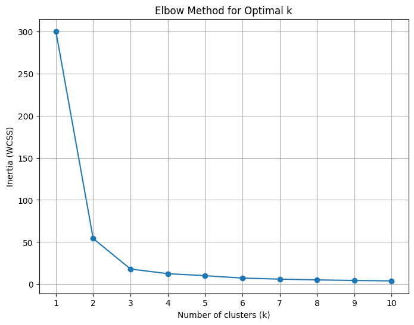

```python
# Plot the elbow curve
plt.figure(figsize=(8, 6))
plt.plot(k_range, inertias, marker='o')
plt.title('Elbow Method for Optimal k')
plt.xlabel('Number of clusters (k)')
plt.ylabel('Inertia (WCSS)')
plt.xticks(k_range)
plt.grid(True)
plt.show()
```

### Optimal value of k

The optimal k is 3 because at this point the inertia starts decreasing more slowly.

## 2. Classification

### Load data

```python
# read heart csv file from Reources folder
df = pd.read_csv("../Resources/heart.csv")
# display top 5 rows
df.head()
```

|  | Age | Sex | ChestPainType | RestingBP | Cholesterol | FastingBS | RestingECG | MaxHR | ExerciseAngina | Oldpeak | ST_Slope | HeartDisease |
| --- | --- | --- | --- | --- | --- | --- | --- | --- | --- | --- | --- | --- |
| 0 | 40 | M | ATA | 140 | 289 | 0 | Normal | 172 | N | 0.0 | Up | 0 |
| 1 | 49 | F | NAP | 160 | 180 | 0 | Normal | 156 | N | 1.0 | Flat | 1 |
| 2 | 37 | M | ATA | 130 | 283 | 0 | ST | 98 | N | 0.0 | Up | 0 |
| 3 | 48 | F | ASY | 138 | 214 | 0 | Normal | 108 | Y | 1.5 | Flat | 1 |
| 4 | 54 | M | NAP | 150 | 195 | 0 | Normal | 122 | N | 0.0 | Up | 0 |

### Remove outliers

```python
# List of features to check for outliers
# Exclude categorical features ('Sex', 'ChestPainType', 'FastingBS', 'RestingECG', 'ExerciseAngina', 'ST_Slope')
features = ['Age', 'RestingBP', 'Cholesterol', 'MaxHR', 'Oldpeak']

# Loop through all numeric features to get the indices of all outliers
df_clean = df.copy()
all_outlier_indices = set()
threshold = 3

for feature in features:
    if feature not in df_clean.columns:
        continue

    z_scores = zscore(df[feature].dropna())
    abs_z_scores = np.abs(z_scores)
    mask = abs_z_scores >= threshold
    outlier_idx = df[feature].dropna().index[mask]

    all_outlier_indices.update(outlier_idx)

# Drop all rows with any outlier in any method/feature
df_clean = df_clean.drop(index=all_outlier_indices)

# Display before and after count
print(f"Before clen: {df.shape}")
print(f"After clen: {df_clean.shape}")
```

```
Before clen: (918, 12)
After clen: (899, 12)
```

### Convert text columns to numbers

**Label encoding**

```python
# Encode specified categorical features using LabelEncoder.
def Label_encode_categorical_features(df, features):
    df_encoded = df.copy()

    for feature in features:
        if feature in df_encoded.columns:
            le = LabelEncoder()
            df_encoded[feature] = le.fit_transform(df_encoded[feature].astype(str))

    return df_encoded

# label encoding features 'ChestPainType', 'RestingECG', 'ST_Slope'
df_encoded = Label_encode_categorical_features(df_clean, ['ChestPainType', 'RestingECG', 'ST_Slope'])
# display top 5 rows of df_encoded
df_encoded.head()
```

|  | Age | Sex | ChestPainType | RestingBP | Cholesterol | FastingBS | RestingECG | MaxHR | ExerciseAngina | Oldpeak | ST_Slope | HeartDisease |
| --- | --- | --- | --- | --- | --- | --- | --- | --- | --- | --- | --- | --- |
| 0 | 40 | M | 1 | 140 | 289 | 0 | 1 | 172 | N | 0.0 | 2 | 0 |
| 1 | 49 | F | 2 | 160 | 180 | 0 | 1 | 156 | N | 1.0 | 1 | 1 |
| 2 | 37 | M | 1 | 130 | 283 | 0 | 2 | 98 | N | 0.0 | 2 | 0 |
| 3 | 48 | F | 0 | 138 | 214 | 0 | 1 | 108 | Y | 1.5 | 1 | 1 |
| 4 | 54 | M | 2 | 150 | 195 | 0 | 1 | 122 | N | 0.0 | 2 | 0 |

**One-hot encoding**

```python
# One-hot encode the specified categorical features.
def one_hot_encode_features(df, features):
    df_encoded = pd.get_dummies(df, columns=features, drop_first=True)
    return df_encoded

# one hot encoding features 'Sex' and 'ExerciseAngina'
df_encoded = one_hot_encode_features(df_encoded, ['Sex', 'ExerciseAngina'])
# display top 5 rows of df_encoded
df_encoded.head()
```

|  | Age | ChestPainType | RestingBP | Cholesterol | FastingBS | RestingECG | MaxHR | Oldpeak | ST_Slope | HeartDisease | Sex_M | ExerciseAngina_Y |
| --- | --- | --- | --- | --- | --- | --- | --- | --- | --- | --- | --- | --- |
| 0 | 40 | 1 | 140 | 289 | 0 | 1 | 172 | 0.0 | 2 | 0 | True | False |
| 1 | 49 | 2 | 160 | 180 | 0 | 1 | 156 | 1.0 | 1 | 1 | False | False |
| 2 | 37 | 1 | 130 | 283 | 0 | 2 | 98 | 0.0 | 2 | 0 | True | False |
| 3 | 48 | 0 | 138 | 214 | 0 | 1 | 108 | 1.5 | 1 | 1 | False | True |
| 4 | 54 | 2 | 150 | 195 | 0 | 1 | 122 | 0.0 | 2 | 0 | True | False |

### Apply scaling

```python
# Apply StandardScaler to specified numeric features.
def scale_numeric_features(df, features):
    scaler = StandardScaler()
    df_scaled = df.copy()

    df_scaled[features] = scaler.fit_transform(df[features])

    return df_scaled


# Fit the scaler to the data and transform it
df_scaled = scale_numeric_features(df_encoded, ['Age', 'RestingBP', 'Cholesterol', 'MaxHR', 'Oldpeak'])
# Display top 5 rows
df_scaled.head()
```

|  | Age | ChestPainType | RestingBP | Cholesterol | FastingBS | RestingECG | MaxHR | Oldpeak | ST_Slope | HeartDisease | Sex_M | ExerciseAngina_Y |
| --- | --- | --- | --- | --- | --- | --- | --- | --- | --- | --- | --- | --- |
| 0 | -1.428154 | 1 | 0.465900 | 0.849636 | 0 | 1 | 1.384320 | -0.855469 | 2 | 0 | True | False |
| 1 | -0.475855 | 2 | 1.634714 | -0.168122 | 0 | 1 | 0.752973 | 0.137516 | 1 | 1 | False | False |
| 2 | -1.745588 | 1 | -0.118507 | 0.793612 | 0 | 2 | -1.535661 | -0.855469 | 2 | 0 | True | False |
| 3 | -0.581666 | 0 | 0.349019 | 0.149344 | 0 | 1 | -1.141069 | 0.634008 | 1 | 1 | False | True |
| 4 | 0.053200 | 2 | 1.050307 | -0.028064 | 0 | 1 | -0.588640 | -0.855469 | 2 | 0 | True | False |

### Data for model training

```python
# Split the dataset
X = df_scaled.drop(columns=['HeartDisease'])
y = df_scaled['HeartDisease']

# Split into train and test sets
X_train, X_test, y_train, y_test = train_test_split(X, y, test_size=0.3, random_state=42, stratify=y)
```

### Train classification models (SVM, logistic regression, random forest)

```python
# Initialize models
models = {
    "SVM (RBF Kernel)": SVC(kernel='rbf', random_state=42),
    "Logistic Regression": LogisticRegression(random_state=42),
    "Random Forest": RandomForestClassifier(n_estimators=100, random_state=42)
}
```

```python
# Function to train and evaluate models
def evaluate_models(X_train, X_test, y_train, y_test):
    results = {}
    for name, model in models.items():
        model.fit(X_train, y_train)
        y_pred = model.predict(X_test)
        acc = accuracy_score(y_test, y_pred)
        results[name] = acc
    return results
```

```python
# === Without PCA ===
results_original = evaluate_models(X_train, X_test, y_train, y_test)
```

### Accuracy comparison

```python
# Print results
print("Model Accuracy Comparison:\n")
for model_name, accuracy in results_original.items():
    print(f"{model_name:20s}: {accuracy:.4f}")
```

[output not shown]

**Random Forest has the best accuracy**

### PCA

```python
# === With PCA (2 Components) ===
pca = PCA(n_components=2)
X_train_pca = pca.fit_transform(X_train)
X_test_pca = pca.transform(X_test)

results_pca = evaluate_models(X_train_pca, X_test_pca, y_train, y_test)
```

```python
# Print results
print("Model Accuracy Comparison:\n")
for model_name, accuracy in results_pca.items():
    print(f"{model_name:20s}: {accuracy:.4f}")
```

[output not shown]

**Conclusion:**

PCA slightly reduces the accuracy because it compresses feature information. However, the models still perform very well with just 2 principal components.